# Часть 1

## Задание 1

Генерация стандартно распределенной генеральной совокупности

```r
N <- 200
X1 <- rnorm(N,0,1)
```

$$ r_1 \in [0.1; 0.2], \quad r_2 \in [0.6; 0.9]$$

```r
r_1 <- .15
r_2 <- .8
```

Построить еще две выборки `X2` и `X3` $$ X2 = r_{1} X1 + \sqrt{1 - r_{1}^{2} }*rnorm(N, 0, 1) $$ $$ X3 = r_{2} X1 + \sqrt{1 - r_{2}^{2} }*rnorm(N, 0, 1) $$

```r
X2 <- r_1 * X1 + sqrt(1 - r_1^2) * rnorm(N,0,1)
X3 <- r_2 * X1 + sqrt(1 - r_2^2) * rnorm(N,0,1)
```

Диаграммы рассеяния для  
`X1 и X2`  
`X1 и X3`  
`X2 и X3`

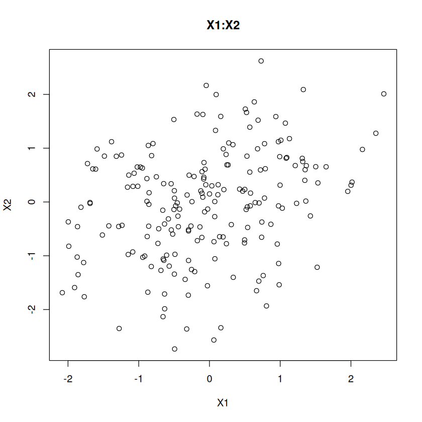

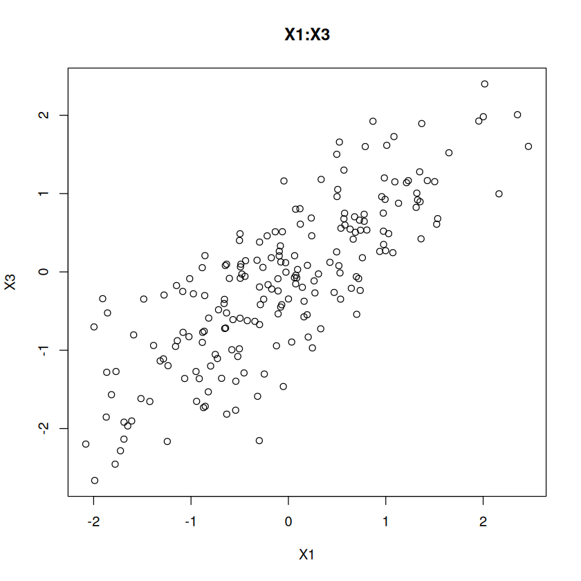

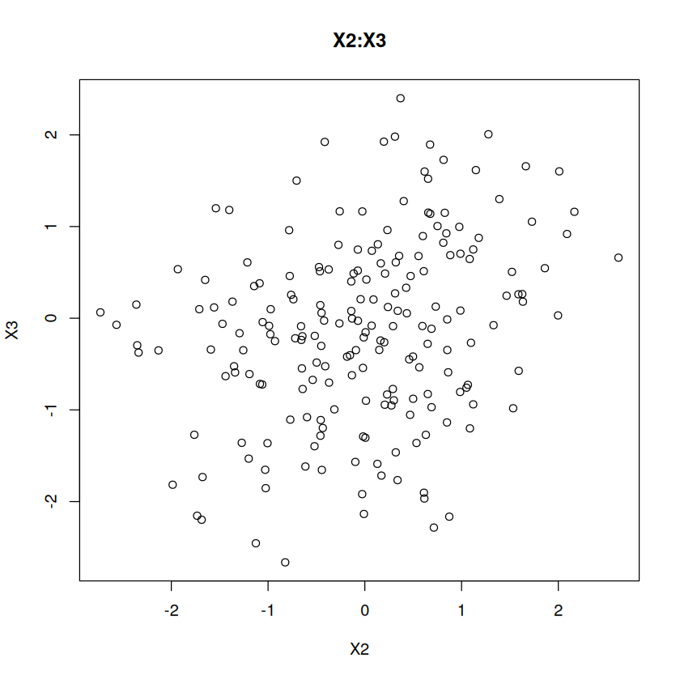

```r
plot(X1,X2,type='p', main='X1:X2')
plot(X1,X3,type='p', main='X1:X3')
plot(X2,X3,type='p', main='X2:X3')
```

Парные коэффиценты корреляции  
$\hat{r}_{1}$

$\hat{r}_{2}$  
$\hat{r}_{3}$

```r
r_1_estimate <- cor(X1,X2)
r_2_estimate <- cor(X1,X3)
r_3_estimate <- cor(X2,X3)
r_1_estimate
r_2_estimate
r_3_estimate
```

0.300328203546133

0.805505815051383

0.268427780059906

```r
t_statistic_1 <- cor.test(X1,X2)$estimate
t_statistic_2 <- cor.test(X1,X3)$estimate
t_statistic_3 <- cor.test(X2,X2)$estimate
t_statistic_1
t_statistic_2
t_statistic_3
```

**cor:** 0.300328203546133

**cor:** 0.805505815051383

**cor:** 1

Построить доверительный интервал для корреляционного коэффициента с помощью Z-преобразования Фишера.
Критическое значение z-статистики для уровня доверия 95% `z <- qnorm(0.975)` для двустороннего доверительного интервала.
$$\text{Left bound} = z_{r} - z_{1-\frac{\alpha}{2}}\frac{1}{\sqrt{n-3}}$$ $$\text{Right bound} = z_{r} + z_{1-\frac{\alpha}{2}} \times \frac{1}{\sqrt{n-3}}$$ $$z_{r} = \frac{1}{2} \ln \left( \frac{1 + r}{1 - r} \right)$$

```r
z_25 <- qnorm(0.975)
Z_Fisher_transform_1 <- 0.5 * log((1 + t_statistic_1) / (1 - t_statistic_1))

left_bound_1 <- tanh(Z_Fisher_transform_1 - z_25 / sqrt(N - 3))
right_bound_1 <- tanh(Z_Fisher_transform_1 + z_25 / sqrt(N - 3))

Z_Fisher_transform_2 <- 0.5 * log((1 + t_statistic_2) / (1 - t_statistic_2))

left_bound_2 <- tanh(Z_Fisher_transform_2 - z_25 / sqrt(N - 3))
right_bound_2 <- tanh(Z_Fisher_transform_2 + z_25 / sqrt(N - 3))

Z_Fisher_transform_3 <- 0.5 * log((1 + t_statistic_3) / (1 - t_statistic_3))

left_bound_3 <- tanh(Z_Fisher_transform_3 - z_25 / sqrt(N - 3))
right_bound_3 <- tanh(Z_Fisher_transform_3 + z_25 / sqrt(N - 3))

cat(left_bound_1, ' ', right_bound_1, '\n')
cat(left_bound_2, ' ', right_bound_2, '\n')
cat(left_bound_3, ' ', right_bound_3, '\n')
```

```
0.1686129   0.421506
0.7506556   0.8493287
1   1
```

## Задание 2

Парные коэффициенты корреляции Спирмена

```r
spearman_estimate_1 <- cor.test(X1,X2,method = "spearman")$estimate
spearman_estimate_2 <- cor.test(X1,X3,method = "spearman")$estimate
spearman_estimate_3 <- cor.test(X2,X3,method = "spearman")$estimate

spearman_estimate_1
spearman_estimate_2
spearman_estimate_3
```

**rho:** 0.296678916972924

**rho:** 0.804332108302708

**rho:** 0.26775969399235

```r
cor.test(X1,X2,method = "spearman")
cor.test(X1,X3,method = "spearman")
cor.test(X2,X3,method = "spearman")
```

```
	Spearman's rank correlation rho

data:  X1 and X2
S = 937738, p-value = 2.171e-05
alternative hypothesis: true rho is not equal to 0
sample estimates:
      rho
0.2966789
```

```
	Spearman's rank correlation rho

data:  X1 and X3
S = 260884, p-value < 2.2e-16
alternative hypothesis: true rho is not equal to 0
sample estimates:
      rho
0.8043321
```

```
	Spearman's rank correlation rho

data:  X2 and X3
S = 976296, p-value = 0.0001336
alternative hypothesis: true rho is not equal to 0
sample estimates:
      rho
0.2677597
```

# Часть 2

```r
n <- 50
p <- .2
q1 <- .5
q2 <- .3
```

```r
n_matrix <- matrix(0, nrow = 2, ncol = 2)
rownames(n_matrix) <- c("A", "NOT A")
colnames(n_matrix) <- c("B", "NOT B")
```

```r
n1 <- rbinom(1, n, p)
n2 <- n - n1
```

```r
n_matrix[1, 1] <- rbinom(1, n1, q1)
n_matrix[1, 2] <- n1 - n_matrix[1, 1]
n_matrix[2, 1] <- rbinom(1, n2, q2)
n_matrix[2, 2] <- n2 - n_matrix[2, 1]
n_matrix
```

A matrix: 2 × 2 of type dbl

|  | B | NOT B |
| --- | --- | --- |
| A | 10 | 9 |
| NOT A | 8 | 23 |

Подлкючение пакета rcompanion для нахождения коэффицента Крамера

```r
library(rcompanion)
```

```r
chisq.test(n_matrix)
```

```
	Pearson's Chi-squared test with Yates' continuity correction

data:  n_matrix
X-squared = 2.607, df = 1, p-value = 0.1064
```

```r
cramerV(n_matrix)
```

**Cramer V:** 0.2713

```r
cramerV(n_matrix, ci=TRUE)
```

A data.frame: 1 × 3

| Cramer.V <dbl> | lower.ci <dbl> | upper.ci <dbl> |
| --- | --- | --- |
| 0.2713 | 0.02257 | 0.5546 |

## Часть 3

- n : Индекс. Тип данных : Порядковая
- rent : Стоимость аренды. Тип данных : Количественный
- s : Площадь. Тип данных : Количественный
- floor : Этаж. Тип данных : Ранговый
- rooms : Количество комнат. Тип данных : Количественный
- walls : Тип стен. Тип данных : Номинальный  
  `По датафрейму можно предположить, что перменная означает есть ли стены. Но здравый рассудок подсказывает {кирпич, дерево} или иначе`
- district : Район. Тип данных : Номинальный

Целевая перменная: Стоимость аренды (rent)

```r
data <- read.csv("./Data/RentR.csv", sep=';')
data$s <- as.numeric(gsub(",", ".", data$s))
```

```r
data
```

A data.frame: 130 × 7

| n <int> | rent <int> | s <dbl> | floor <int> | rooms <int> | walls <int> | district <int> |
| --- | --- | --- | --- | --- | --- | --- |
| 1 | 11000 | 36 | 6 | 1 | 0 | 1 |
| 2 | 11000 | 33 | 1 | 1 | 0 | 4 |
| 3 | 12000 | 44 | 3 | 2 | 0 | 1 |
| 4 | 12000 | 64 | 9 | 2 | 0 | 1 |
| 5 | 10000 | 20 | 3 | 1 | 1 | 2 |
| 6 | 8000 | 19 | 5 | 1 | 1 | 1 |
| 7 | 16000 | 50 | 5 | 2 | 1 | 3 |
| 8 | 12000 | 44 | 3 | 1 | 1 | 3 |
| 9 | 13000 | 43 | 5 | 2 | 0 | 4 |
| 10 | 13000 | 40 | 2 | 1 | 1 | 3 |
| 11 | 18000 | 70 | 9 | 3 | 0 | 3 |
| 12 | 16000 | 54 | 12 | 2 | 0 | 2 |
| 13 | 15000 | 60 | 5 | 3 | 1 | 1 |
| 14 | 8000 | 16 | 2 | 1 | 1 | 1 |
| 15 | 18000 | 45 | 5 | 1 | 1 | 2 |
| 16 | 20000 | 65 | 8 | 2 | 1 | 3 |
| 17 | 6000 | 14 | 3 | 1 | 1 | 3 |
| 18 | 15000 | 44 | 5 | 1 | 0 | 2 |
| 19 | 15000 | 50 | 3 | 2 | 1 | 3 |
| 20 | 9000 | 20 | 2 | 1 | 1 | 1 |
| 21 | 12000 | 54 | 3 | 3 | 1 | 4 |
| 22 | 20000 | 54 | 7 | 2 | 1 | 2 |
| 23 | 10000 | 21 | 2 | 1 | 1 | 3 |
| 24 | 12000 | 40 | 1 | 1 | 1 | 1 |
| 25 | 17500 | 45 | 3 | 1 | 1 | 3 |
| 26 | 19000 | 70 | 9 | 3 | 0 | 2 |
| 27 | 16000 | 43 | 7 | 1 | 1 | 2 |
| 28 | 14000 | 35 | 5 | 1 | 1 | 3 |
| 29 | 8500 | 28 | 7 | 1 | 1 | 1 |
| 30 | 8000 | 19 | 2 | 1 | 1 | 4 |
| ⋮ | ⋮ | ⋮ | ⋮ | ⋮ | ⋮ | ⋮ |
| 101 | 14000 | 40 | 12 | 1 | 0 | 2 |
| 102 | 9000 | 24 | 1 | 1 | 1 | 3 |
| 103 | 13000 | 44 | 4 | 1 | 0 | 1 |
| 104 | 13000 | 48 | 5 | 2 | 1 | 1 |
| 105 | 15000 | 65 | 4 | 2 | 1 | 3 |
| 106 | 11000 | 36 | 2 | 1 | 0 | 3 |
| 107 | 13000 | 40 | 4 | 2 | 0 | 4 |
| 108 | 13000 | 43 | 5 | 2 | 1 | 3 |
| 109 | 13000 | 33 | 2 | 1 | 0 | 4 |
| 110 | 15000 | 54 | 1 | 2 | 0 | 4 |
| 111 | 10000 | 35 | 4 | 1 | 1 | 3 |
| 112 | 13000 | 40 | 12 | 1 | 0 | 4 |
| 113 | 13000 | 68 | 4 | 2 | 0 | 1 |
| 114 | 11000 | 33 | 4 | 1 | 0 | 2 |
| 115 | 7500 | 15 | 1 | 1 | 0 | 4 |
| 116 | 10000 | 30 | 8 | 1 | 1 | 1 |
| 117 | 13000 | 60 | 4 | 2 | 0 | 1 |
| 118 | 13000 | 38 | 2 | 2 | 0 | 4 |
| 119 | 8000 | 16 | 1 | 1 | 1 | 1 |
| 120 | 20000 | 66 | 6 | 3 | 0 | 4 |
| 121 | 6000 | 20 | 2 | 1 | 1 | 2 |
| 122 | 20000 | 50 | 4 | 2 | 1 | 2 |
| 123 | 10000 | 30 | 2 | 1 | 1 | 4 |
| 124 | 9000 | 30 | 8 | 1 | 1 | 2 |
| 125 | 10500 | 31 | 3 | 1 | 1 | 2 |
| 126 | 10000 | 36 | 4 | 1 | 1 | 4 |
| 127 | 7000 | 30 | 1 | 2 | 1 | 4 |
| 128 | 7500 | 20 | 3 | 1 | 1 | 1 |
| 129 | 8000 | 17 | 3 | 1 | 1 | 1 |
| 130 | 11000 | 30 | 8 | 1 | 1 | 1 |

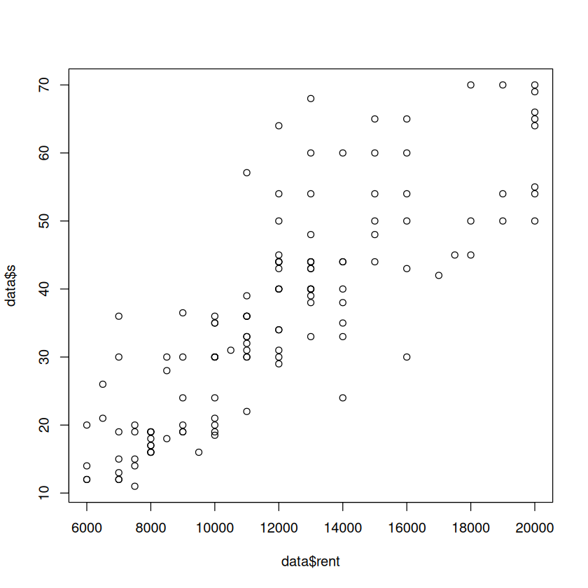

```r
plot(data$rent, data$s , type='p')
```

```r
cor.test(data$rent, data$s)
```

```
	Pearson's product-moment correlation

data:  data$rent and data$s
t = 17.085, df = 128, p-value < 2.2e-16
alternative hypothesis: true correlation is not equal to 0
95 percent confidence interval:
 0.7724688 0.8796590
sample estimates:
      cor
0.8337581
```

R Позваляет создать таблицу корреляций Пирсона.

```r
cor(data[ ,-1])
```

A matrix: 6 × 6 of type dbl

|  | rent | s | floor | rooms | walls | district |
| --- | --- | --- | --- | --- | --- | --- |
| rent | 1.00000000 | 0.83375810 | 0.337566502 | 0.61037695 | -0.09914057 | 0.037417190 |
| s | 0.83375810 | 1.00000000 | 0.403467071 | 0.73781255 | -0.23180586 | 0.013806891 |
| floor | 0.33756650 | 0.40346707 | 1.000000000 | 0.15305188 | -0.14751679 | 0.002571095 |
| rooms | 0.61037695 | 0.73781255 | 0.153051878 | 1.00000000 | -0.25051030 | 0.071913646 |
| walls | -0.09914057 | -0.23180586 | -0.147516794 | -0.25051030 | 1.00000000 | -0.107366243 |
| district | 0.03741719 | 0.01380689 | 0.002571095 | 0.07191365 | -0.10736624 | 1.000000000 |

Исключая из DataFrame те переменные, которые не подходят для теста Пирсона.

> Правильно ли, что этаж не корректно оценивать тестом Пирсона?

```r
cor( data[, c("rent", "s", "rooms")])
```

A matrix: 3 × 3 of type dbl

|  | rent | s | rooms |
| --- | --- | --- | --- |
| rent | 1.0000000 | 0.8337581 | 0.6103769 |
| s | 0.8337581 | 1.0000000 | 0.7378126 |
| rooms | 0.6103769 | 0.7378126 | 1.0000000 |

*Есть зависимость между количеством комнат и площадью.*

```r
cor.test(data$rooms , data$s)
```

```
	Pearson's product-moment correlation

data:  data$rooms and data$s
t = 12.366, df = 128, p-value < 2.2e-16
alternative hypothesis: true correlation is not equal to 0
95 percent confidence interval:
 0.6479417 0.8074228
sample estimates:
      cor
0.7378126
```

Тестом $\chi^2$ произведу оценку корреляции номанальных переменных.

```r
chisq.test(data$walls, data$district)
```

```
	Pearson's Chi-squared test

data:  data$walls and data$district
X-squared = 11.089, df = 3, p-value = 0.01125
```

```r
if ( chisq.test(data$walls, data$district)$p.value < 0.05) { cat("Есть корреляция!") }
```

```
Есть корреляция!
```

```r
cor.test(data$rent,data$floor,method = "spearman")
```

```
	Spearman's rank correlation rho

data:  data$rent and data$floor
S = 228770, p-value = 1.091e-05
alternative hypothesis: true rho is not equal to 0
sample estimates:
      rho
0.3751932
```